# Gene Expression Analysis and Interpretation

Install of required libraries, for this work we will be needing: BiocManager, that handles the libraries DESeq2, clusterProfiler, org.Hs.eg.db, pathview and ReactomePA. We also will be using enrichplot, pheatmap and glmnet. All of this are on conditional so they wor’t run if already installed.

```r
if (!require("BiocManager", quietly = TRUE))
  install.packages("BiocManager")

if (!require("DESeq2", quietly = TRUE))
    BiocManager::install("DESeq2")

if (!requireNamespace("clusterProfiler", quietly = TRUE))
  BiocManager::install("clusterProfiler")

if (!requireNamespace("org.Hs.eg.db", quietly = TRUE))
  BiocManager::install("org.Hs.eg.db")

if (!requireNamespace("enrichplot", quietly = TRUE))
  install.packages("enrichplot")

if (!requireNamespace("pathview", quietly = TRUE))
  BiocManager::install("pathview")

if (!requireNamespace("ReactomePA", quietly = TRUE))
  BiocManager::install("ReactomePA")

if (!requireNamespace("pheatmap", quietly = TRUE))
  install.packages("pheatmap")

if (!require("glmnet", quietly = TRUE))
  install.packages("glmnet")
```

Now we import all the libraries that will be used in the code. This are all grouped to maintain a clean code.

```r
library(DESeq2)
library(clusterProfiler)
library(enrichplot)
library(org.Hs.eg.db)
library(ReactomePA)
library(pathview)
library(pheatmap)
library(survival)
library(glmnet)
```

Set seed to keep result across different compilations.

```r
set.seed(48)
```

Unziping and reading of the files

```r
file_path <- paste(getwd(),"brca_tcga_pan_can_atlas_2018.tar.gz", sep = "/")
untar(file_path)

folder_path <- paste(getwd(),"brca_tcga_pan_can_atlas_2018", sep = "/")

RNA_seq_path <- paste(folder_path,"data_mrna_seq_v2_rsem.txt", sep = "/")
data_clinical_patient_path <- file.path(folder_path,"data_clinical_patient.txt")
data_cna_path <- paste(folder_path,"data_cna.txt", sep = "/")

RNA_seq <- read.delim(RNA_seq_path)
data_clinical_patient <- read.delim(data_clinical_patient_path)
data_cna <- read.delim(data_cna_path)
```

Standardising function for the IDs.

```r
standar_id <- function(x) {
  x <- gsub("\\.","-",x)
  substr(x,1,12)
}
```

Filtering datasets and collecting the IDs

```r
RNA_cols <- 3:ncol(RNA_seq)
RNA_ids <- colnames(RNA_seq)[RNA_cols]
RNA_ids_std <- standar_id(RNA_ids)

cna_cols <- 3:ncol(data_cna)
cna_ids <- colnames(data_cna)[cna_cols]
cna_ids_std <- standar_id(cna_ids)

clin_rows <- 5:nrow(data_clinical_patient)
clin_ids <- data_clinical_patient$X.Patient.Identifier[clin_rows]
clin_ids_std <- standar_id(clin_ids)
```

Reduce datasets to common IDs

```r
common_ids <- Reduce(intersect, list(RNA_ids_std,cna_ids_std,clin_ids_std))


RNA_seq_common <- RNA_seq[, c(1,2,RNA_cols[RNA_ids_std %in% common_ids])]
cna_common <- data_cna[, c(1,2,cna_cols[cna_ids_std %in% common_ids])]
clinic_common <- data_clinical_patient[clin_rows[clin_ids_std %in% common_ids],]
```

Creating metadata with ERBB2 gen info and cancer stage. Stage is transformed into I-V. ERBB2 is taken into a binary state where 0 means Not Amplified, and 1 means Amplified

```r
col_stage <- which(colnames(clinic_common) ==
                    "Neoplasm.Disease.Stage.American.Joint.Committee.on.Cancer.Code")

stage <- clinic_common[,col_stage]
stage <- gsub("I[^VI]", "I", stage)
stage <- gsub("V[^\\s]", "V", stage)

stage_factor <- as.factor(stage)

erbb2_row <- which(cna_common$Hugo_Symbol == "ERBB2")
erbb2_status <- 1*(as.numeric(cna_common[erbb2_row,3:ncol(cna_common)])>0)

assay <- round(as.matrix(RNA_seq_common[,-c(1,2)]))
rownames(assay) <- RNA_seq_common[,1];
colnames(assay) <- c(standar_id(colnames(assay)))

metaData <- matrix(0, dim(assay)[2],2)

for (i in 1:dim(assay)[2]){
  pat_barcode <- standar_id(colnames(assay)[i])
  idx <- which(pat_barcode == common_ids)
  metaData[i,1] <- erbb2_status[i]
  metaData[i,2] <- stage_factor[idx]
}

metaData[is.na(metaData)] <- 0

colnames(metaData) <- c("ERBB2", "Stage")
```

Normalising the data

```r
#Normalization of the data with DESeq
#Fill na values and replace negative numbers with 0
assay[is.na(assay)] <- 0
assay[assay<0] <- 0

smallestGroupSize <- 3
keep <- rowSums(assay >= 10) >= smallestGroupSize
assay = assay[keep,]

dds <- DESeqDataSetFromMatrix(countData = assay,
                              colData = metaData,
                              design = ~ ERBB2)

dds <- DESeq(dds)
```

Checking the top 10 genes

```r
res[order(res$padj)[1:10],]
```

```
log2 fold change (MLE): ERBB2
Wald test p-value: ERBB2
DataFrame with 10 rows and 6 columns
          baseMean log2FoldChange     lfcSE      stat       pvalue         padj
         <numeric>      <numeric> <numeric> <numeric>    <numeric>    <numeric>
ERBB2    18302.597        2.84504 0.0776838   36.6233 1.21729e-293 2.26404e-289
PSMD3     5074.459        2.05796 0.0577281   35.6492 2.42218e-278 2.25251e-274
STARD3    1703.229        2.19292 0.0626905   34.9802 4.50257e-268 2.79144e-264
C17orf37  1972.660        2.43337 0.0708182   34.3608 9.70104e-259 4.51074e-255
GRB7      1309.927        2.63513 0.0782626   33.6703 1.57376e-248 5.85407e-245
PGAP3     1929.690        2.29149 0.0711470   32.2078 1.37047e-227 4.24824e-224
ORMDL3    3982.237        2.07221 0.0660085   31.3931 2.51283e-216 6.67658e-213
MED1      2543.443        1.83704 0.0598585   30.6897 7.81508e-207 1.81691e-203
MSL1      3083.400        1.41119 0.0492542   28.6512 1.54877e-180 3.20062e-177
FBXL20     244.919        1.63814 0.0576919   28.3946 2.35469e-177 4.37949e-174
```

Top 10 Differentially expressed genes ordered by Fold Change

```r
res[order(abs(res$log2FoldChange), decreasing = TRUE)[1:10], ]
```

```
log2 fold change (MLE): ERBB2
Wald test p-value: ERBB2
DataFrame with 10 rows and 6 columns
         baseMean log2FoldChange     lfcSE      stat      pvalue        padj
        <numeric>      <numeric> <numeric> <numeric>   <numeric>   <numeric>
CSN2     18.52793       -4.56354  0.845434  -5.39787 6.74381e-08 5.32431e-07
SPANXA2   2.34148        4.35182  0.636209   6.84023 7.90639e-12 1.33804e-10
GAGE12D  10.26094        4.29677  0.796620   5.39375 6.90016e-08 5.43107e-07
SPANXC    2.42993        4.17245  0.524365   7.95716 1.76030e-15 5.73377e-14
GAGE2B    1.52261        4.05698  1.412768   2.87165 4.08332e-03 9.81590e-03
CSN3     47.14761       -3.70971  0.492304  -7.53540 4.86839e-14 1.25238e-12
FAM9C     1.69449        3.37450  0.297925  11.32670 9.67862e-30 1.32362e-27
PNMT    165.00060        3.30959  0.179624  18.42513 8.25934e-76 5.90828e-73
GAGE4     4.45378        3.30569  0.670901   4.92725 8.33954e-07 5.10220e-06
LALBA    22.78384       -3.29068  0.729214  -4.51265 6.40239e-06 3.18561e-05
```

Variance Stabilized Transformed expression values and PCA analysis by ERBB2 gen and by Stage

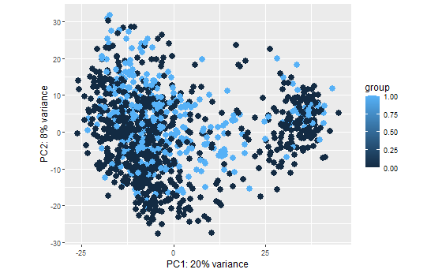

```r
vst <- vst(dds)

plotPCA(vst, intgroup = c("ERBB2"))
```

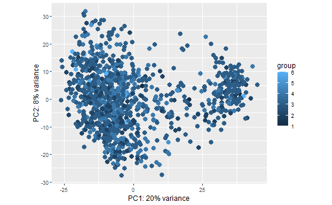

```r
plotPCA(vst, intgroup = c("Stage"))
```

Getting subsets of differentially expressed genes by under and over expressed

```r
res_sig = res[res$padj<0.05,]


DE_over = rownames(res_sig[res_sig$log2FoldChange>0,])
DE_under = rownames(res_sig[res_sig$log2FoldChange<0,])
```

Pathway enrichment of over and under expressed

EnrichGoO

```r
go_results_over = enrichGO(
  gene          = DE_over,
  OrgDb         = org.Hs.eg.db,
  keyType       = "SYMBOL",
  ont           = "BP",
  pAdjustMethod = "BH",
  pvalueCutoff  = 0.05,
  qvalueCutoff  = 0.05
)


print(head(go_results_over))
```

|  | ID | Description | GeneRatio | BgRatio | RichFactor | FoldEnrichment | zScore | pvalue | p.adjust | qvalue | geneID | Count |
| --- | --- | --- | --- | --- | --- | --- | --- | --- | --- | --- | --- | --- |
| GO:0007059 | GO:0007059 | chromosome segregation | 165/3296 | 434/18860 | 0.3801843 | 2.175448 | 11.400531 | 7.431364e-25 | 4.554683e-21 | 3.879955e-21 | ACTL6A/ACTR2/ACTR3/ANAPC11/ANAPC1/ANAPC7/ANKRD31/APC/ARL8B/A…… | 165 |
| GO:0098813 | GO:0098813 | nuclear chromosome segregation | 127/3296 | 323/18860 | 0.3931889 | 2.249861 | 10.426428 | 7.394672e-21 | 2.266097e-17 | 1.930399e-17 | ACTL6A/ACTR2/ACTR3/ANAPC11/ANAPC1/ANAPC7/ANKRD31/APC/ASPM/AU…… | 127 |
| GO:0000819 | GO:0000819 | sister chromatid segregation | 99/3296 | 233/18860 | 0.4248927 | 2.431273 | 10.116292 | 2.573795e-19 | 5.258264e-16 | 4.479307e-16 | ACTL6A/ANAPC11/ANAPC1/ANAPC7/APC/AURKB/BECN1/BIRC5/BRD7/BUB1…… | 99 |
| GO:0000280 | GO:0000280 | nuclear division | 157/3296 | 453/18860 | 0.3465784 | 1.983152 | 9.746988 | 4.373159e-19 | 6.700773e-16 | 5.708124e-16 | ACTR2/ACTR3/ANAPC11/ANAPC7/ANKLE2/ANKRD31/ANLN/APC/ASPM/AURK…… | 157 |
| GO:0000070 | GO:0000070 | mitotic sister chromatid segregation | 85/3296 | 192/18860 | 0.4427083 | 2.533216 | 9.826465 | 4.101959e-18 | 5.028181e-15 | 4.283308e-15 | ANAPC11/ANAPC7/APC/AURKB/BECN1/BIRC5/BUB1/BUB1B/CCNB1/CDC23/…… | 85 |
| GO:0140014 | GO:0140014 | mitotic nuclear division | 109/3296 | 281/18860 | 0.3879004 | 2.219600 | 9.478762 | 1.397861e-17 | 1.427915e-14 | 1.216384e-14 | ANAPC11/ANAPC7/ANKLE2/ANLN/APC/AURKA/AURKB/BECN1/BIRC5/BUB1/…… | 109 |

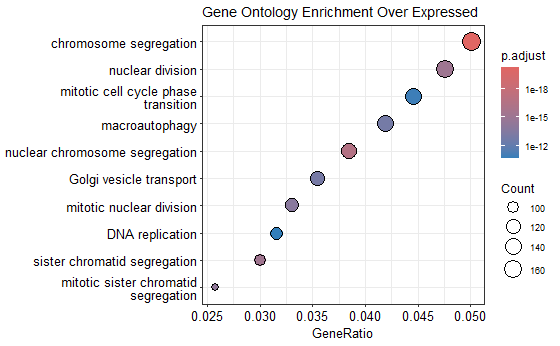

```r
dotplot(go_results_over, showCategory=10) + ggtitle("Gene Ontology Enrichment Over Expressed")
```

```r
go_results_under = enrichGO(
  gene          = DE_under,
  OrgDb         = org.Hs.eg.db,
  keyType       = "SYMBOL",
  ont           = "BP",
  pAdjustMethod = "BH",
  pvalueCutoff  = 0.05,
  qvalueCutoff  = 0.05
)

print(head(go_results_under))
```

|  | ID | Description | GeneRatio | BgRatio | RichFactor | FoldEnrichment | zScore | pvalue | p.adjust | qvalue | geneID | Count |
| --- | --- | --- | --- | --- | --- | --- | --- | --- | --- | --- | --- | --- |
| GO:0007159 | GO:0007159 | leukocyte cell-cell adhesion | 203/4265 | 439/18860 | 0.4624146 | 2.044816 | 11.97380 | 2.036078e-28 | 1.267662e-24 | 9.134488e-25 | ADD2/AGER/AIF1/ALOX5/ANXA1/ARID1B/BAD/BCL10/BCL6/BTLA/CARD11…… | 203 |
| GO:0050867 | GO:0050867 | positive regulation of cell activation | 189/4265 | 401/18860 | 0.4713217 | 2.084203 | 11.86303 | 8.317715e-28 | 2.589305e-24 | 1.865795e-24 | ACTA2/AGER/AIF1/ANXA1/ARID1B/BAD/BCL10/BCL2/BCL6/BST1/BTK/CA…… | 189 |
| GO:1903037 | GO:1903037 | regulation of leukocyte cell-cell adhesion | 187/4265 | 401/18860 | 0.4663342 | 2.062148 | 11.62171 | 8.144281e-27 | 1.690210e-23 | 1.217927e-23 | AGER/AIF1/ALOX5/ANXA1/ARID1B/BAD/BCL10/BCL6/BTLA/CARD11/CAV1…… | 187 |
| GO:0030098 | GO:0030098 | lymphocyte differentiation | 199/4265 | 441/18860 | 0.4512472 | 1.995433 | 11.43444 | 3.339211e-26 | 4.294869e-23 | 3.094786e-23 | ANXA1/ARID1B/ARMC5/BAD/BATF/BCL11B/BCL2/BCL3/BCL6/BLNK/BTK/C…… | 199 |
| GO:0002696 | GO:0002696 | positive regulation of leukocyte activation | 179/4265 | 381/18860 | 0.4698163 | 2.077546 | 11.48619 | 3.449140e-26 | 4.294869e-23 | 3.094786e-23 | AGER/AIF1/ANXA1/ARID1B/BAD/BCL10/BCL2/BCL6/BST1/BTK/CARD11/C…… | 179 |
| GO:0070661 | GO:0070661 | leukocyte proliferation | 170/4265 | 356/18860 | 0.4775281 | 2.111648 | 11.44660 | 6.301582e-26 | 6.538942e-23 | 4.711815e-23 | AGER/AHR/AIF1/ANXA1/ARMC5/BCL2/BCL6/BST1/BTK/BTLA/CARD11/CCD…… | 170 |

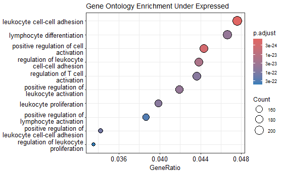

```r
dotplot(go_results_under, showCategory=10) + ggtitle("Gene Ontology Enrichment Under Expressed")
```

EnrichKEGG

```r
gene_entrez_over <- bitr(
  DE_over,
  fromType = "SYMBOL",
  toType   = "ENTREZID",
  OrgDb    = org.Hs.eg.db
)

kegg_results_over =  enrichKEGG(
  gene          = gene_entrez_over[,2],
  organism      = "human",
  pAdjustMethod = "BH",
  pvalueCutoff  = 0.05,
  qvalueCutoff  = 0.05
)

print(head(kegg_results_over))
```

|  | category | subcategory | ID | Description | GeneRatio | BgRatio | RichFactor | FoldEnrichment | zScore | pvalue | p.adjust | qvalue | geneID | Count |
| --- | --- | --- | --- | --- | --- | --- | --- | --- | --- | --- | --- | --- | --- | --- |
| hsa03050 | Genetic Information Processing | Folding, sorting and degradation | hsa03050 | Proteasome | 27/1689 | 46/9512 | 0.5869565 | 3.305583 | 7.283125 | 5.648598e-10 | 1.954415e-07 | 1.504311e-07 | 11047/51371/5682/5683/5684/5685/5686/5687/5688/5691/5693/5695/5704/5705/5706/5717/5718/10213/5707/5708/5709/5710/9861/5713/5714/10197/9491 | 27 |
| hsa04137 | Cellular Processes | Transport and catabolism | hsa04137 | Mitophagy - animal | 45/1689 | 105/9512 | 0.4285714 | 2.413601 | 6.767637 | 1.570881e-09 | 2.717624e-07 | 2.091752e-07 | 23786/598/8678/664/10241/1457/1459/1869/1965/11345/3091/3265…… | 45 |
| hsa04141 | Genetic Information Processing | Folding, sorting and degradation | hsa04141 | Protein processing in endoplasmic reticulum | 62/1689 | 172/9512 | 0.3604651 | 2.030044 | 6.334142 | 6.261658e-09 | 7.221779e-07 | 5.558595e-07 | 22926/10134/821/10970/1603/79139/3301/10294/5611/80331/85479…… | 62 |
| hsa03013 | Genetic Information Processing | Translation | hsa03013 | Nucleocytoplasmic transport | 44/1689 | 108/9512 | 0.4074074 | 2.294410 | 6.285920 | 1.557777e-08 | 1.147904e-06 | 8.835405e-07 | 25909/22794/1434/55308/9775/9670/79711/10527/55705/3836/3838…… | 44 |
| hsa05022 | Human Diseases | Neurodegenerative disease | hsa05022 | Pathways of neurodegeneration - multiple diseases | 134/1689 | 483/9512 | 0.2774327 | 1.562427 | 5.894697 | 1.658821e-08 | 1.147904e-06 | 8.835405e-07 | 55860/10121/11047/57679/317/324/22926/488/489/6311/11273/598…… | 134 |
| hsa05014 | Human Diseases | Neurodegenerative disease | hsa05014 | Amyotrophic lateral sclerosis | 107/1689 | 371/9512 | 0.2884097 | 1.624247 | 5.698857 | 5.744268e-08 | 3.312528e-06 | 2.549649e-06 | 71/55860/10121/11047/57679/310/317/22926/6311/11273/598/8678…… | 107 |

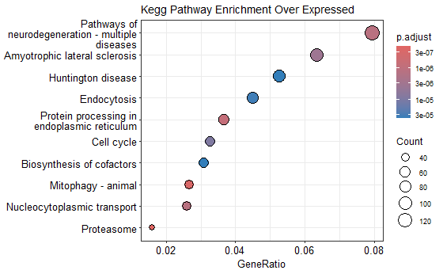

```r
dotplot(kegg_results_over, showCategory=10) + ggtitle("Kegg Pathway Enrichment Over Expressed")
```

```r
gene_entrez_under <- bitr(
  DE_under,
  fromType = "SYMBOL",
  toType   = "ENTREZID",
  OrgDb    = org.Hs.eg.db
)


kegg_results_under =  enrichKEGG(
  gene          = gene_entrez_under[,2],
  organism      = "human",
  pAdjustMethod = "BH",
  pvalueCutoff  = 0.05,
  qvalueCutoff  = 0.05
)

print(head(kegg_results_under))
```

|  | category | subcategory | ID | Description | GeneRatio | BgRatio | RichFactor | FoldEnrichment | zScore | pvalue | p.adjust | qvalue | geneID | Count |
| --- | --- | --- | --- | --- | --- | --- | --- | --- | --- | --- | --- | --- | --- | --- |
| hsa04640 | Organismal Systems | Immune system | hsa04640 | Hematopoietic cell lineage | 65/2190 | 100/9512 | 0.6500000 | 2.823196 | 10.023347 | 2.820682e-19 | 9.787765e-17 | 5.819511e-17 | 290/929/930/909/910/911/912/913/933/914/945/947/948/951/915/…… | 65 |
| hsa04060 | Environmental Information Processing | Signaling molecules and interaction | hsa04060 | Cytokine-cytokine receptor interaction | 136/2190 | 298/9512 | 0.4563758 | 1.982213 | 9.421284 | 2.027752e-18 | 3.518150e-16 | 2.091786e-16 | 130399/94/650/653/6357/6358/6360/6361/6363/6364/6366/6367/63…… | 136 |
| hsa05171 | Human Diseases | Infectious disease: viral | hsa05171 | Coronavirus disease - COVID-19 | 111/2190 | 238/9512 | 0.4663866 | 2.025694 | 8.763808 | 4.512759e-16 | 5.219758e-14 | 3.103512e-14 | 712/713/715/716/718/720/727/729/730/733/834/629/1675/1437/14…… | 111 |
| hsa04820 | Cellular Processes | Cell motility | hsa04820 | Cytoskeleton in muscle cells | 104/2190 | 233/9512 | 0.4463519 | 1.938676 | 7.933470 | 1.393614e-13 | 1.208960e-11 | 7.188116e-12 | 58/70/72/89/375790/270/271/287/26287/480/481/482/825/93661/8…… | 104 |
| hsa04514 | Environmental Information Processing | Signaling molecules and interaction | hsa04514 | Cell adhesion molecule (CAM) interaction | 79/2190 | 160/9512 | 0.4937500 | 2.144543 | 7.984731 | 1.940856e-13 | 1.346954e-11 | 8.008584e-12 | 23705/57863/933/29126/940/914/947/958/959/920/923/925/926/83…… | 79 |
| hsa04064 | Environmental Information Processing | Signal transduction | hsa04064 | NF-kappa B signaling pathway | 57/2190 | 105/9512 | 0.5428571 | 2.357834 | 7.651316 | 3.193793e-12 | 1.847077e-10 | 1.098217e-10 | 8915/596/597/330/29760/695/29775/84433/6357/6363/6366/929/95…… | 57 |

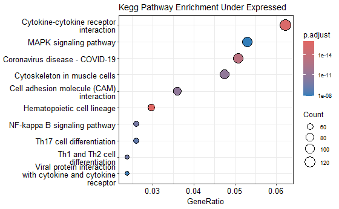

```r
dotplot(kegg_results_under, showCategory=10) + ggtitle("Kegg Pathway Enrichment Under Expressed")
```

EnrichPathway

```r
reactome_results_over =  enrichPathway(
  gene          = gene_entrez_over[,2],
  organism      = "human",
  pAdjustMethod = "BH",
  pvalueCutoff  = 0.05,
  qvalueCutoff  = 0.05,
)

print(head(reactome_results_over))
```

|  | ID | Description | GeneRatio | BgRatio | RichFactor | FoldEnrichment | zScore | pvalue | p.adjust | qvalue | geneID | Count |
| --- | --- | --- | --- | --- | --- | --- | --- | --- | --- | --- | --- | --- |
| R-HSA-69278 | R-HSA-69278 | Cell Cycle, Mitotic | 179/2039 | 479/10173 | 0.3736952 | 1.864444 | 9.703151 | 1.697112e-19 | 2.593187e-16 | 1.963290e-16 | 10121/11047/25909/10393/64682/51434/23141/10776/6790/9212/69…… | 179 |
| R-HSA-68882 | R-HSA-68882 | Mitotic Anaphase | 90/2039 | 187/10173 | 0.4812834 | 2.401224 | 9.682609 | 3.280227e-18 | 2.506094e-15 | 1.897353e-15 | 11047/25909/10393/64682/51434/23141/9212/699/701/891/9133/86…… | 90 |
| R-HSA-2555396 | R-HSA-2555396 | Mitotic Metaphase and Anaphase | 90/2039 | 188/10173 | 0.4787234 | 2.388452 | 9.620450 | 5.082704e-18 | 2.588791e-15 | 1.959962e-15 | 11047/25909/10393/64682/51434/23141/9212/699/701/891/9133/86…… | 90 |
| R-HSA-69620 | R-HSA-69620 | Cell Cycle Checkpoints | 106/2039 | 244/10173 | 0.4344262 | 2.167444 | 9.241402 | 3.752302e-17 | 1.433379e-14 | 1.085205e-14 | 11047/25909/10393/64682/51434/9212/641/79184/83990/699/701/8…… | 106 |
| R-HSA-2467813 | R-HSA-2467813 | Separation of Sister Chromatids | 74/2039 | 153/10173 | 0.4836601 | 2.413082 | 8.817368 | 2.407717e-15 | 6.183801e-13 | 4.681729e-13 | 11047/25909/10393/64682/51434/9212/699/701/8697/113130/1062/…… | 74 |
| R-HSA-69242 | R-HSA-69242 | S Phase | 67/2039 | 132/10173 | 0.5075758 | 2.532402 | 8.872193 | 2.428194e-15 | 6.183801e-13 | 4.681729e-13 | 11047/10393/64682/51434/890/595/9134/8697/994/8318/990/11313…… | 67 |

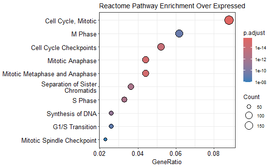

```r
dotplot(reactome_results_over, showCategory=10) + ggtitle("Reactome Pathway Enrichment Over Expressed")
```

```r
reactome_results_under =  enrichPathway(
  gene          = gene_entrez_under[,2],
  organism      = "human",
  pAdjustMethod = "BH",
  pvalueCutoff  = 0.05,
  qvalueCutoff  = 0.05,
)

print(head(reactome_results_under))
```

|  | ID | Description | GeneRatio | BgRatio | RichFactor | FoldEnrichment | zScore | pvalue | p.adjust | qvalue | geneID | Count |
| --- | --- | --- | --- | --- | --- | --- | --- | --- | --- | --- | --- | --- |
| R-HSA-156842 | R-HSA-156842 | Eukaryotic Translation Elongation | 66/2505 | 91/10173 | 0.7252747 | 2.945397 | 10.65422 | 6.349658e-22 | 5.240449e-19 | 4.510312e-19 | 1915/1933/1938/2197/6134/4736/6136/6137/23521/9045/6138/6139…… | 66 |
| R-HSA-156902 | R-HSA-156902 | Peptide chain elongation | 65/2505 | 89/10173 | 0.7303371 | 2.965956 | 10.64678 | 6.950198e-22 | 5.240449e-19 | 4.510312e-19 | 1915/1938/2197/6134/4736/6136/6137/23521/9045/6138/6139/6141…… | 65 |
| R-HSA-2408557 | R-HSA-2408557 | Selenocysteine synthesis | 65/2505 | 93/10173 | 0.6989247 | 2.838388 | 10.17922 | 3.344390e-20 | 1.669169e-17 | 1.436608e-17 | 60678/2197/118672/6134/4736/6136/6137/23521/9045/6138/6139/6…… | 65 |
| R-HSA-192823 | R-HSA-192823 | Viral mRNA Translation | 63/2505 | 89/10173 | 0.7078652 | 2.874696 | 10.15255 | 4.427503e-20 | 1.669169e-17 | 1.436608e-17 | 2197/6134/4736/6136/6137/23521/9045/6138/6139/6141/6142/6144…… | 63 |
| R-HSA-975956 | R-HSA-975956 | Nonsense Mediated Decay (NMD) independent of the Exon Junction Complex (EJC) | 64/2505 | 92/10173 | 0.6956522 | 2.825098 | 10.05065 | 9.676945e-20 | 2.827079e-17 | 2.433190e-17 | 2197/23708/6134/4736/6136/6137/23521/9045/6138/6139/6141/614…… | 64 |
| R-HSA-9954714 | R-HSA-9954714 | PELO:HBS1L and ABCE1 dissociate a ribosome on a non-stop mRNA | 63/2505 | 90/10173 | 0.7000000 | 2.842754 | 10.03598 | 1.124832e-19 | 2.827079e-17 | 2.433190e-17 | 2197/6134/4736/6136/6137/23521/9045/6138/6139/6141/6142/6144…… | 63 |

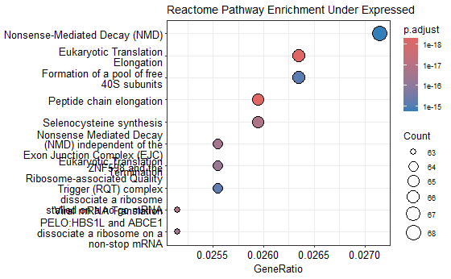

```r
dotplot(reactome_results_under, showCategory=10) + ggtitle("Reactome Pathway Enrichment Under Expressed")
```

Tree Plots

GO Enrichment

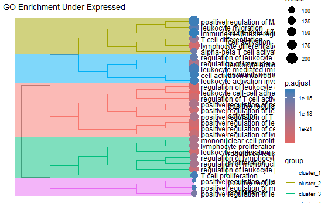

```r
go_results_under_pw = pairwise_termsim(go_results_under)
treeplot(go_results_under_pw)+ ggtitle("GO Enrichment Under Expressed")
```

KEGG Enrichment

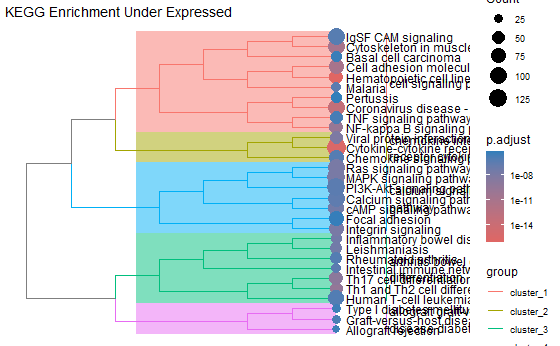

```r
kegg_results_under_pw = pairwise_termsim(kegg_results_under)
treeplot(kegg_results_under_pw)+ ggtitle("KEGG Enrichment Under Expressed")
```

Heatmap of Amplified/Not_amplified

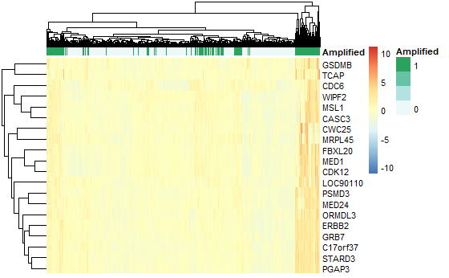

```r
top_DE = order(res$padj)

vsd_DE = assay(vst)[top_DE[1:20],]

annotation_colors = list(Amplified = c(Amplified = "#1f78b4", Not_Amplified = "#33a02c"))

annotation_col = data.frame(Amplified = as.matrix(metaData[,1]))
rownames(annotation_col) = colnames(vst)

pheatmap(
  vsd_DE,
  cluster_rows = TRUE,
  cluster_cols = TRUE,
  scale = 'row',
  show_colnames = FALSE,
  show_rownames = TRUE,
  annotation_col = annotation_col
  )
```

Survival Model

Histogram of overall survival months

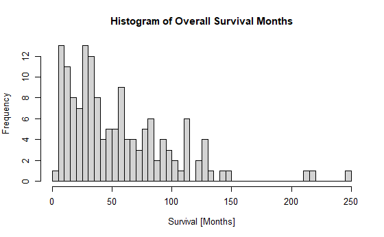

```r
col_OS <- which(colnames(clinic_common) == "Overall.Survival.Status")
uncensored <- which(clinic_common[,col_OS] == "1:DECEASED")

col_OS_T <- which(colnames(clinic_common) == "Overall.Survival..Months.")

hist(as.numeric(clinic_common[uncensored,col_OS_T]), breaks = 50,
     main = "Histogram of Overall Survival Months",
     xlab = "Survival [Months]")
```

Setting the event threshold

```r
status <- clinic_common[,col_OS]
time <- as.numeric(clinic_common[,col_OS_T])
time[time<=0] <- 0.1

event <- ifelse(status == "1:DECEASED",1,0)
```

Creating the model with glmnet

```r
x <- t(vsd_DE)
y <- Surv(time = time,
          event = event)
cvfit <- cv.glmnet(x,y,
                   family = "cox",
                   alpha = 1,
                   nfolds = 10)
```

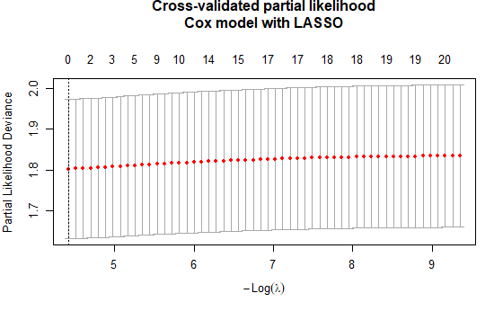

```r
par(mar = c(5, 4, 6, 2) + 0.1)
plot(cvfit, main = "")

title("Cross-validated partial likelihood\nCox model with LASSO",
      line = 4,
      cex.main = 1.3)
```

```r
cvfit$lambda.min
```

```
[1] 0.01204353
```

```r
cvfit$lambda.1se
```

```
[1] 0.01204353
```

Checking the active genes

```r
coef_min <- coef(cvfit, s = "lambda.min")
active_genes <- rownames(coef_min)[as.numeric(coef_min) != 0]
active_genes
```

```
character(0)
```

Checking the lambda due to no active genes

```r
lambda_seq <- cvfit$lambda
min(lambda_seq)
```

```
[1] 8.696405e-05
```

Changing the lambda threshold, and recheking for active genes

```r
lambda_small <- cvfit$lambda.min / 2

coef_small <- coef(cvfit, s = lambda_small)
active_genes_small <- rownames(coef_small)[as.numeric(coef_small) != 0]
active_genes_small
```

```
[1] "STARD3"   "ORMDL3"   "MED24"    "GSDMB"    "LOC90110"
```

Cheking coefficient paths

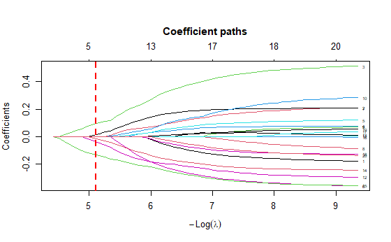

```r
par(mar = c(5, 4, 6, 2) + 0.1)
plot(cvfit$glmnet.fit, xvar = "lambda", label = TRUE,
     main = "Coefficient paths")
abline(v = -log(lambda_small), col = "red", lwd = 2, lty = 2)
```

Survival rates prediction

```r
risk_score <- predict(cvfit, newx = x, s = "lambda.min", type = "link")

risk_group <- ifelse(risk_score > median(risk_score), "High", "Low")

fit_km <- survfit(Surv(time, event) ~ risk_group)
```

[figure not shown]

```r
plot(fit_km, col = c("blue", "red"), lwd = 2,
     main = "Survival rates",
     xlab = "Time", ylab = "Survival probability")

legend("bottomleft", legend = c("Low risk", "High risk"),
       col = c("blue", "red"), lwd = 2)
```